# Assignment 3

Sumayyah Musa

2/19/2021

## Read in the data

```r
data <- read.csv("simulated_data_missing.csv")
```

## Print the data object

```r
glimpse(data)
```

```
## Rows: 10,000
## Columns: 5
## $ id                  <int> 1, 2, 3, 4, 5, 6, 7, 8, 9, 10, 11, 12, 13, 14, ...
## $ age_years           <dbl> 38.62033, 35.26406, 55.00560, 21.77767, 49.3928...
## $ bench_press_max_lbs <dbl> 122.34489, 133.98912, 85.90034, 216.96535, 95.6...
## $ height_cm           <dbl> 161.0401, 151.7275, 511.0000, 147.2229, 145.197...
## $ weight_kg           <dbl> 54.07658, 24.98297, 55.13407, 65.85491, 67.4311...
```

## Variable Analysis - HEIGHT

- Variable type - Quantitative, Numeric, Continuous

```r
summary(data$height_cm)
```

```
##    Min. 1st Qu.  Median    Mean 3rd Qu.    Max.    NA's
##    52.0   145.4   154.9   154.9   164.4   511.0      28
```

### Are there outliers?

There appear to be outliers based on the summary statistics above. The minimum and maximum heights which are 52.0cm and 511.0cm are not possible. More exploratory analysis of the variable is needed to see if there are other outliers.

#### Let’s plot an histogram of height

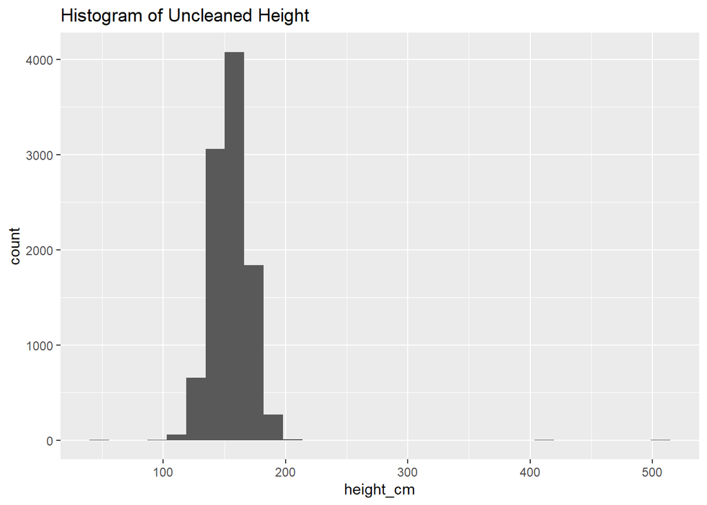

```r
hist_height <- ggplot(data = data, aes(height_cm)) +
                  geom_histogram() +
                ggtitle("Histogram of Uncleaned Height")
plot(hist_height)
```

The histogram indicates that there are values outside the distribution. A boxplot will give more information about the outliers.

#### Let’s make a boxplot for height

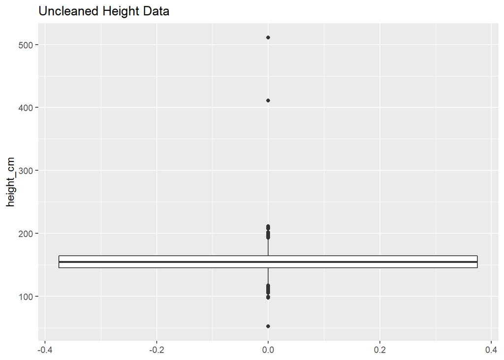

```r
box_height <- ggplot(data = data, aes(height_cm)) +
                  geom_boxplot() +
                  ggtitle("Uncleaned Height Data") +
                  coord_flip()
plot(box_height)
```

The boxplot shows that there are three extreme values in the height data. It could be that the values were recorded in feet and inches instead of centimeters. Let’s sort the variable in both ascending and descending orders to see the exact values of the extreme values.

```r
#arrange in descending order
head(arrange(data, desc(height_cm)), 10)
```

```
##      id age_years bench_press_max_lbs height_cm weight_kg
## 1     3  55.00560            85.90034  511.0000  55.13407
## 2  9724  76.26837            61.95229  411.0000  61.85579
## 3  6450  29.98791           157.56352  211.2767  79.67620
## 4  2783  69.36242            68.12046  209.9852 100.36266
## 5  5705  19.93623           237.00569  208.9240  70.72469
## 6  6400  25.53235           185.05933  207.0065  78.26965
## 7  1138  80.17510            58.93351  201.6992  73.81603
## 8  5355  62.21422            75.94727  201.3148  74.02965
## 9  7855  54.40946            86.84151  198.9328  50.12523
## 10 8814  79.18610            59.66957  197.9047  73.64962
```

Above we see the two extreme values that are outside the maximum of the boxplot, 511cm and 411cm. We are going to assume that they were wrongly recorded in Feet and Inches. So 5ft 11inches = 5ft × 30.48 + 11in × 2.54 = 180.34cm, and 4ft 11inches = 4ft × 30.48 + 11in × 2.54 = 149.86cm. Let’s recode these variables.

```r
data <- data %>%
          mutate(height_outlier = case_when(
            height_cm == 411 ~ 149.86,
            height_cm == 511 ~ 180.34,
            TRUE ~ height_cm
          ))
```

Let’s arrange the variable in ascending order to see the extreme values on the low end of the boxplot.

```r
#arranging height in ascending order
head(arrange(data, (height_cm)), 10)
```

```
##      id age_years bench_press_max_lbs height_cm weight_kg height_outlier
## 1    95  78.73057            60.01481  52.00000  98.29190       52.00000
## 2  2079  77.75465            60.76807  97.18847  23.13270       97.18847
## 3  6491  81.55687            57.93504  98.93815  67.38432       98.93815
## 4  8319  28.28573           167.04537 105.23597  58.74066      105.23597
## 5  4593  72.89056            64.82321 105.29581  35.93294      105.29581
## 6   929  53.25763            88.71969 107.23587  28.51314      107.23587
## 7   677  18.55492           254.64947 108.15267  56.83737      108.15267
## 8  6902  27.59727           171.21258 108.49860  40.07078      108.49860
## 9  6520  75.85094            62.29323 109.36121  40.38327      109.36121
## 10 5588  30.35483           155.65893 109.42089  26.53682      109.42089
```

Here we see the lowest values is 52.0cm, we can assume that it was also wrongly recorded in feet and inches instead of centimeters. So 5ft 2inches = 5ft × 30.48 + 2in × 2.54 = 157.48cm. We will also recode this in the data

```r
data <- data %>%
          mutate(height_outlier = case_when(
            height_cm == 411 ~ 149.86,
            height_cm == 511 ~ 180.34,
            height_cm == 52 ~ 157.48,
            TRUE ~ height_cm
          ))
```

From the sorting in ascending order, we noticed that there are some very short people - 97.18cm and 98.93cm, these values might or might not be logical, but we will be removing these two values from our dataset, and keep the NA values when removing them.

```r
height_no_outliers <- filter(data, is.na(height_outlier) | height_outlier > 100)
```

### Comparing the outlier-cleaned data with the uncleaned data

We will compare the boxplots of the height data with and without outliers.

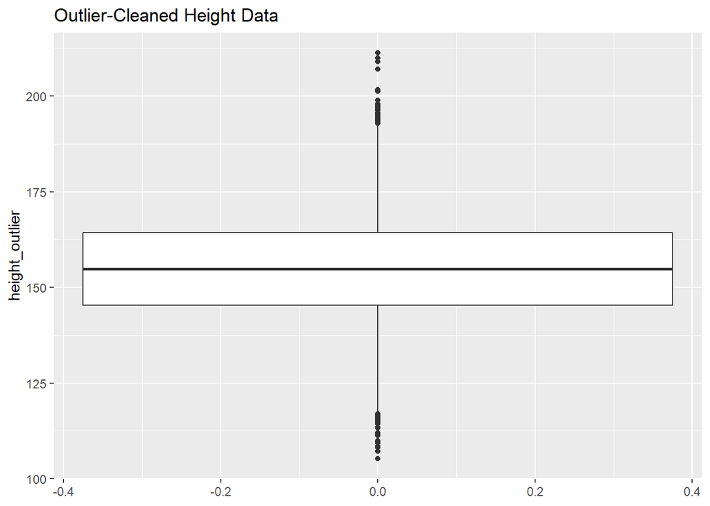

```r
#boxplots
box_height_no_outlier <- ggplot() +
                  geom_boxplot(data = height_no_outliers, aes(height_outlier)) +
                  ggtitle("Outlier-Cleaned Height Data") +
                  coord_flip()
#boxplot for outlier-cleaned data
plot(box_height_no_outlier)
```

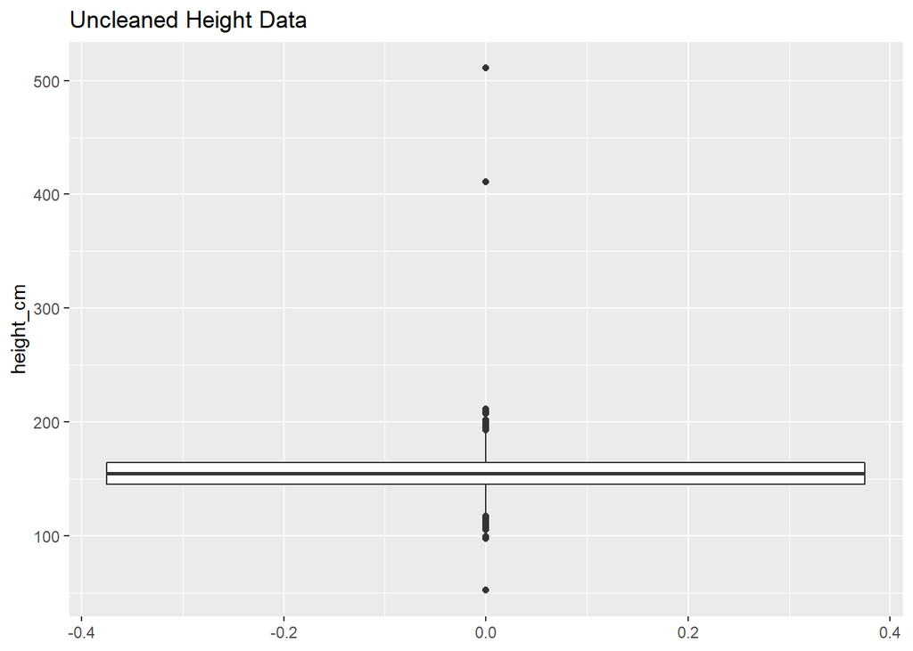

```r
#boxplot for uncleaned data
plot(box_height)
```

## Are there missing data?

We will check for missing data in our outlier-cleaned data: “height_no_outliers”

```r
summary(height_no_outliers$height_outlier)
```

```
##    Min. 1st Qu.  Median    Mean 3rd Qu.    Max.    NA's
##   105.2   145.4   154.9   154.9   164.4   211.3      28
```

The summary function shows that there are 28 missing data. We can also use the is.na function to confirm this.

```r
height_no_outliers %>%
  summarise(count = sum(is.na(height_outlier)))
```

```
##   count
## 1    28
```

The is.na function also confirms that there are 28 missing data in our outlier-cleaned height data. 28 missing values out of 9998 data points is a very small portion of the data. So I will remove the people with missing height values leaving us with 9,970 observations.

```r
height_cleaned_data <- drop_na(height_no_outliers, height_outlier)
```

Now, we have a cleaned dataset for height. Let’s compare the distribution of the uncleaned and cleaned datasets.

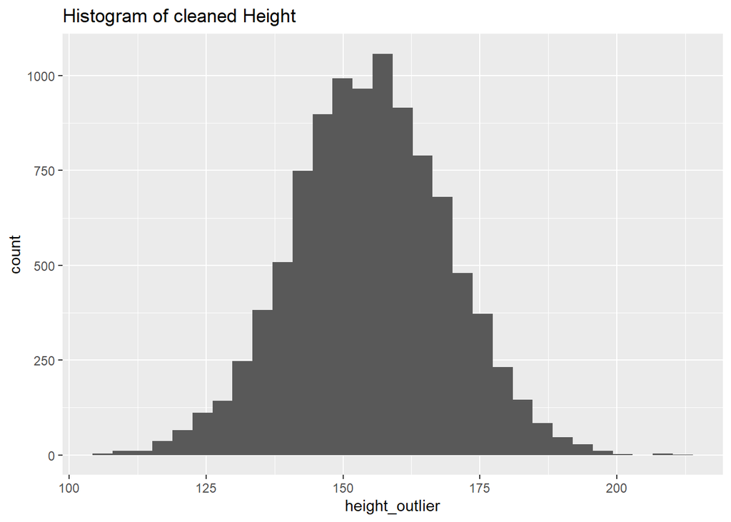

```r
hist_cleaned_height <- ggplot(data = height_cleaned_data, aes(height_outlier)) +
                  geom_histogram() +
                ggtitle("Histogram of cleaned Height")
plot(hist_cleaned_height)
```

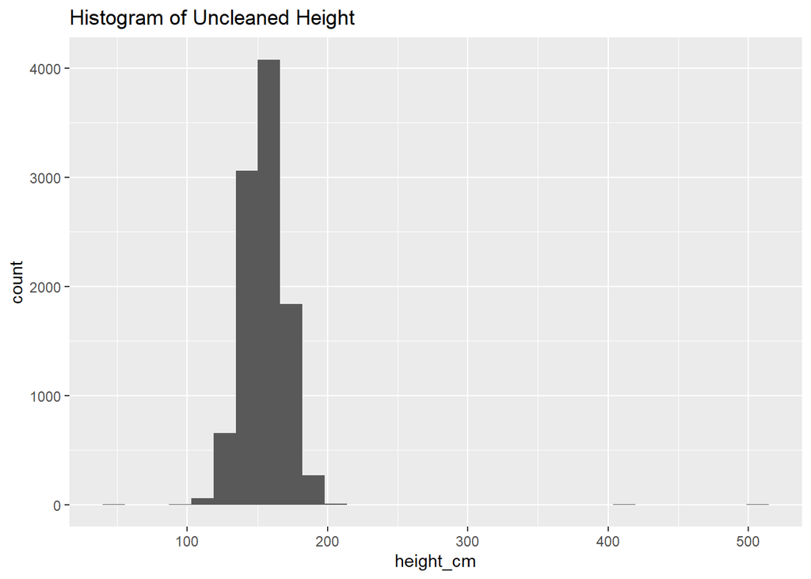

```r
plot(hist_height)
```

The histogram of cleaned height data suggests a normal distribution as opposed to that of the uncleaned height data which suggested that the distribution of height was leptokurtic.

## Variable Analysis - AGE

- Variable type - Quantitative, Numeric, Continuous

We will use the height cleaned data to analyze the age variable.

```r
summary(height_cleaned_data$age_years)
```

```
##    Min. 1st Qu.  Median    Mean 3rd Qu.    Max.    NA's
##   18.01   34.96   51.28   51.50   68.16   84.99      23
```

### Are there outliers?

There appear to be no outlier based on the summary statistics above. The minimum and maximum heights which are 18.01years and 84.99 years which seems possible. Let’s go further in the exploratory analysis of the variable to be certain that there are no outliers.

#### Let’s plot an histogram of age

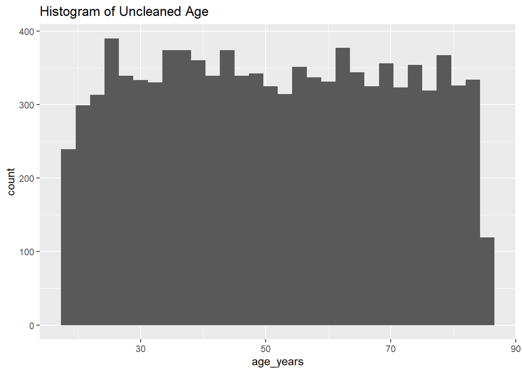

```r
hist_age <- ggplot(data = height_cleaned_data, aes(age_years)) +
                  geom_histogram() +
                ggtitle("Histogram of Uncleaned Age")
plot(hist_age)
```

The histogram indicates that there are no values outside the distribution. A boxplot will give more information about this.

#### Let’s make a boxplot for age

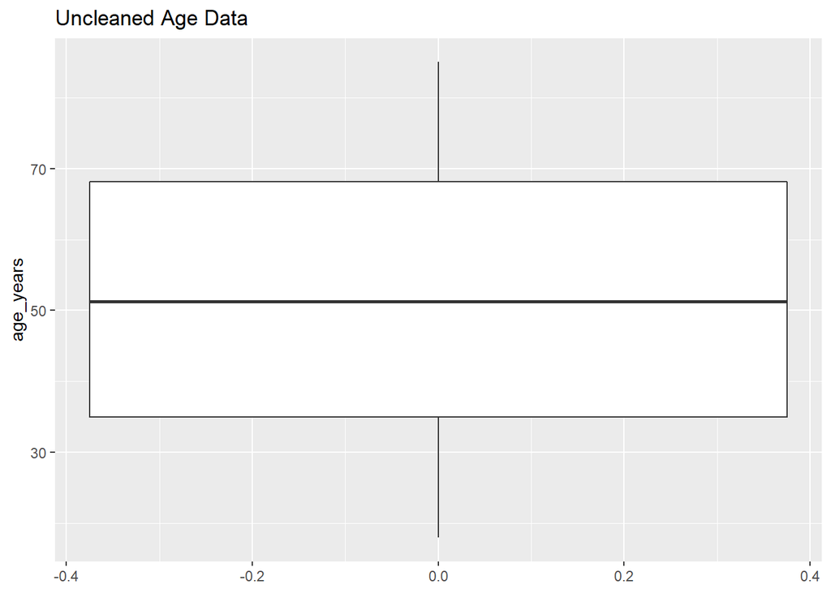

```r
box_age <- ggplot(data = height_cleaned_data, aes(age_years)) +
                  geom_boxplot() +
                  ggtitle("Uncleaned Age Data") +
                  coord_flip()
plot(box_age)
```

The boxplot shows that there are no extreme values/outliers in the age data.

## Are there missing data?

We will check for missing age data in our height cleaned data: “height_cleaned_data”

```r
summary(height_cleaned_data$age_years)
```

```
##    Min. 1st Qu.  Median    Mean 3rd Qu.    Max.    NA's
##   18.01   34.96   51.28   51.50   68.16   84.99      23
```

The summary function shows that there are 23 missing data. We can also use the is.na function to confirm this.

```r
height_cleaned_data %>%
  summarise(count = sum(is.na(age_years)))
```

```
##   count
## 1    23
```

The is.na function also confirms that there are 23 missing data in our cleaned height data. 23 missing values out of 9970 data points is a very small portion of the data. So I will remove the people with missing age values leaving us with 9,947 observations.

```r
age_cleaned_data <- drop_na(height_cleaned_data, age_years)
```

Now, we have a cleaned dataset for age. Let’s compare the distribution of the uncleaned and cleaned datasets.

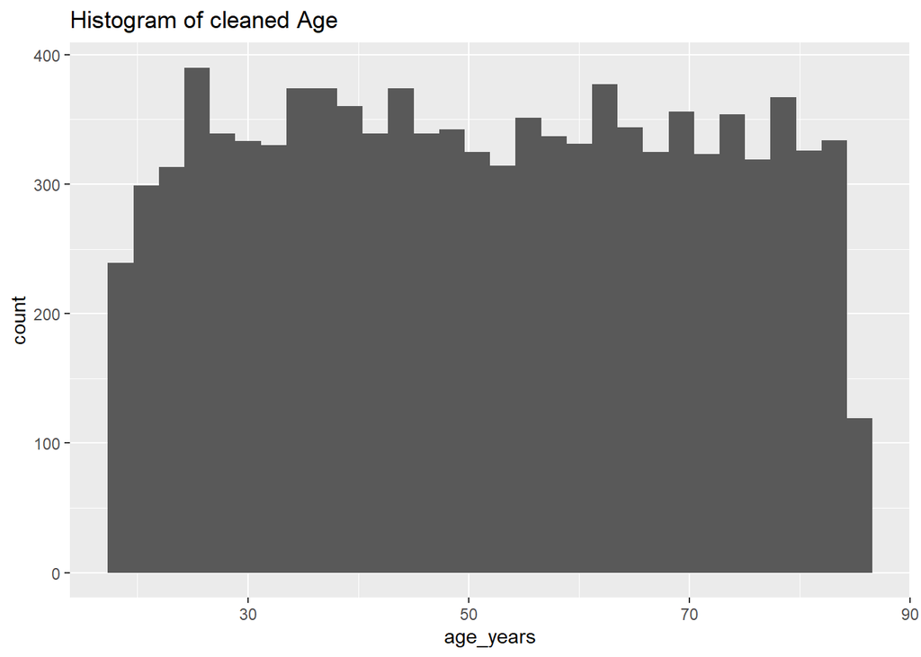

```r
hist_cleaned_age <- ggplot(data = age_cleaned_data, aes(age_years)) +
                  geom_histogram() +
                ggtitle("Histogram of cleaned Age")
plot(hist_cleaned_age)
```

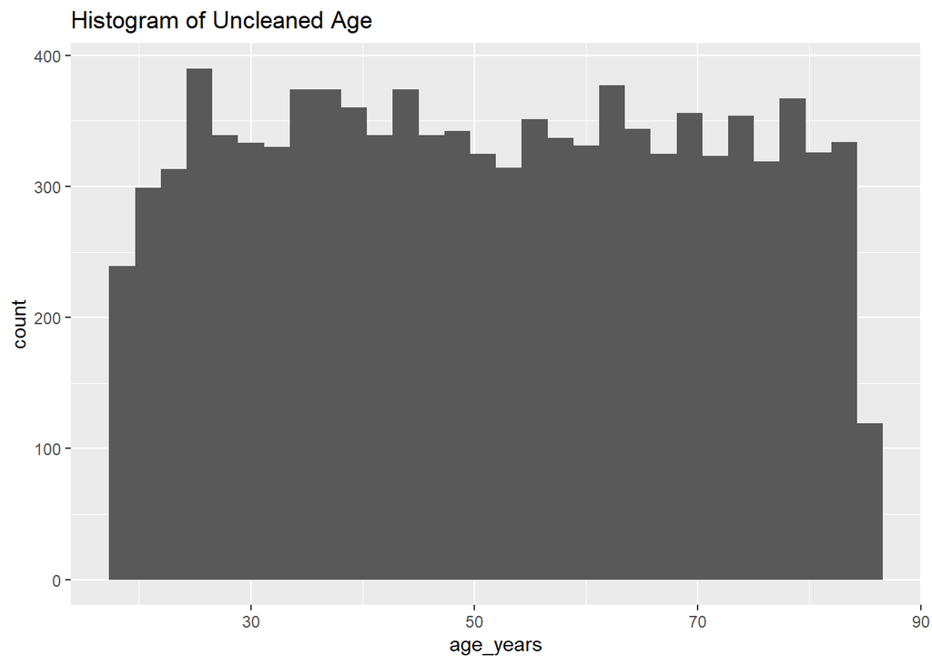

```r
plot(hist_age)
```

There is no difference between the histogram of cleaned age data and the uncleaned age data. Both suggest that the distribution of age is uniform.

### Compare the descriptive statistics of the cleaned and uncleaned age data

```r
summary(age_cleaned_data$age_years)
```

```
##    Min. 1st Qu.  Median    Mean 3rd Qu.    Max.
##   18.01   34.96   51.28   51.50   68.16   84.99
```

```r
summary(height_cleaned_data$age_years)
```

```
##    Min. 1st Qu.  Median    Mean 3rd Qu.    Max.    NA's
##   18.01   34.96   51.28   51.50   68.16   84.99      23
```

There is also no difference in the mean and median of the cleaned age data and that of uncleaned age data.

## Variable Analysis - WEIGHT

- Variable type - Quantitative, Numeric, Continuous

We will use the age cleaned data to analyze weight.

```r
summary(age_cleaned_data$weight_kg)
```

```
##    Min. 1st Qu.  Median    Mean 3rd Qu.    Max.    NA's
##   9.055  51.686  61.972  61.931  72.144 170.000      12
```

### Are there outliers?

There appear to be outliers based on the summary statistics above. The minimum weight is 9.1kg which is not plausible, while the max weight is 170kg which is still logical. More exploratory analysis of the variable is needed to see if there are other outliers.

#### Let’s plot an histogram of weight

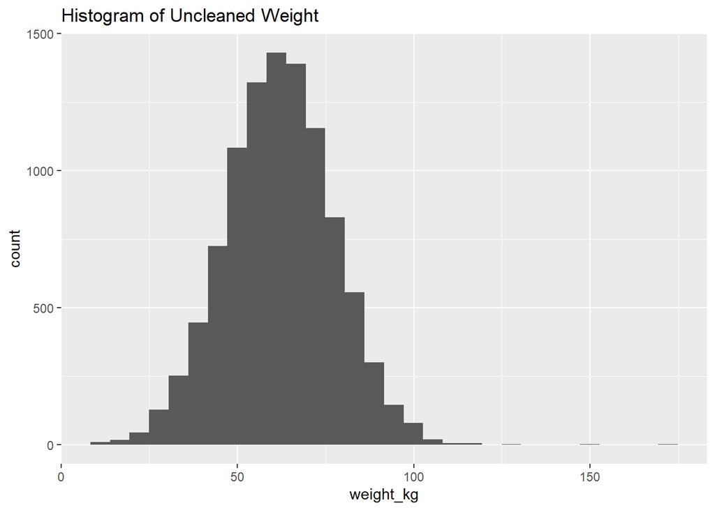

```r
hist_weight <- ggplot(data = age_cleaned_data, aes(weight_kg)) +
                  geom_histogram() +
                ggtitle("Histogram of Uncleaned Weight")
plot(hist_weight)
```

The histogram indicates that there are values outside the distribution. A boxplot will give more information about the outliers.

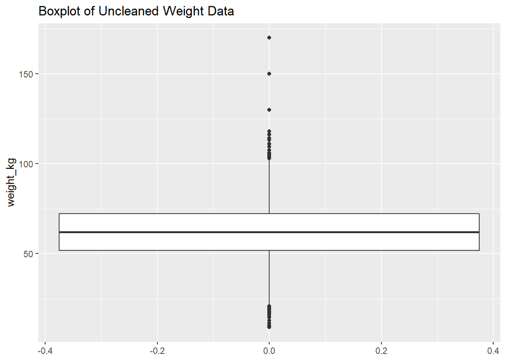

```r
box_weight <- ggplot(data = age_cleaned_data, aes(weight_kg)) +
                  geom_boxplot() +
                  ggtitle("Boxplot of Uncleaned Weight Data") +
                  coord_flip()
plot(box_weight)
```

The boxplot shows that there are three extreme values in the weight data. It could be that the participants were measured in pounds, or they are obese. Let’s sort the variable in both ascending and descending orders to see the exact values of the extreme values.

```r
#arrange in descending order
head(arrange(age_cleaned_data, desc(weight_kg)), 10)
```

```
##      id age_years bench_press_max_lbs height_cm weight_kg height_outlier
## 1   114  34.00692           138.94230  173.0045  170.0000       173.0045
## 2    69  34.42120           137.27004  119.4490  150.0000       119.4490
## 3  9689  46.64394           101.29932  163.4220  130.0000       163.4220
## 4  7569  61.91067            76.31964  182.5638  117.9219       182.5638
## 5  8154  22.51674           209.84392  170.9847  116.3617       170.9847
## 6   911  60.52658            78.06488  173.6261  116.1635       173.6261
## 7  2345  27.54773           171.52050  167.3413  114.2602       167.3413
## 8  6174  79.72294            59.26776  188.6197  113.1065       188.6197
## 9  1527  43.91799           107.58689  150.1467  111.0250       150.1467
## 10 1963  65.92186            71.67577  179.0628  110.9338       179.0628
```

Above we see the three extreme values that are outside the maximum of the boxplot, 170kg, 150kg and 130kg. We are going to assume that they were wrongly recorded in pounds instead of kilograms. So 170lbs = 170/2.205 = 77.11kg, 150lbs = 150/2.205 = 68.04kg, and 130lbs = 130/2.205 = 58.97kg. Let’s recode these variables.

```r
age_cleaned_data <- age_cleaned_data %>%
                mutate(weight_outlier = case_when(
            weight_kg == 170 ~ 77.11,
            weight_kg == 150 ~ 68.04,
            weight_kg == 130 ~ 58.97,
            TRUE ~ weight_kg
          ))
```

Let’s arrange the variable in ascending order to see the extreme values on the low end of the boxplot.

```r
#arranging height in ascending order
head(arrange(age_cleaned_data, (weight_outlier)), 50)
```

```
##      id age_years bench_press_max_lbs height_cm weight_kg height_outlier
## 1  8588  73.39273            64.37967  146.4622  9.055479       146.4622
## 2  8671  81.52115            57.96042  116.8438  9.527783       116.8438
## 3  4850  27.65947           170.82759  135.8115  9.847665       135.8115
## 4  9634  55.26341            85.49962  128.3686  9.876399       128.3686
## 5  5291  56.13930            84.16564  146.8725 10.192736       146.8725
## 6  5068  52.14240            90.61724  135.8064 11.442282       135.8064
## 7  1329  39.44335           119.79205  146.3271 11.476698       146.3271
## 8  4059  59.19218            79.82474  115.9540 12.955322       115.9540
## 9  5019  36.05194           131.06091  144.2707 14.437547       144.2707
## 10 5223  75.18072            62.84856  124.7141 14.976176       124.7141
## 11 9603  22.73999           207.78370  137.1318 15.167269       137.1318
## 12 4858  34.41867           137.28015  140.1364 16.126422       140.1364
## 13 6161  84.24404            56.08705  144.3311 17.055235       144.3311
## 14 2229  25.78733           183.22949  147.1309 17.125954       147.1309
```

[output cut: 87 more lines]

Here we see the lowest values is 9kg and the least 50 values were barely above 23kg, there is no logical explanation for these. It could be that the decimal points were wrongly placed, and/or most of them were measured in pounds and not kilograms. we will leave the values like that but we will be removing the four values that are less than 10kg from our dataset, and keep the NA values when removing them.

```r
weight_no_outliers <- filter(age_cleaned_data, is.na(weight_outlier) | weight_outlier > 10)
```

### Comparing the outlier-cleaned data with the uncleaned data

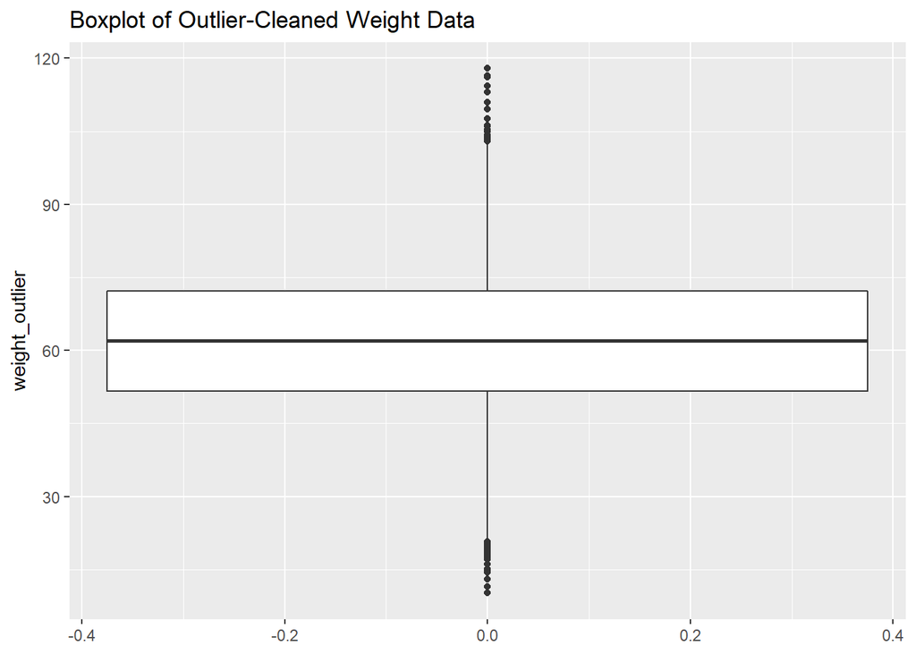

```r
#boxplots
box_weight_no_outlier <- ggplot() +
                  geom_boxplot(data = weight_no_outliers, aes(weight_outlier)) +
                  ggtitle("Boxplot of Outlier-Cleaned Weight Data") +
                  coord_flip()
#boxplot for outlier-cleaned data
plot(box_weight_no_outlier)
```

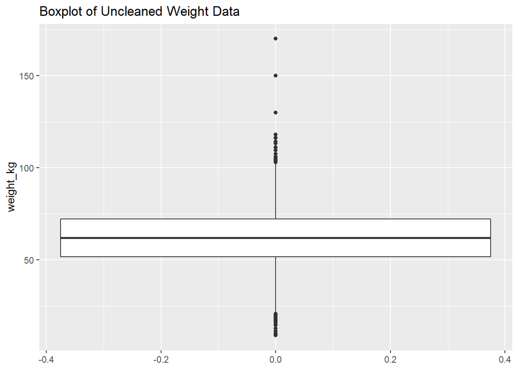

```r
#boxplot for uncleaned data
plot(box_weight)
```

## Are there missing data?

We will check for missing data in our outlier-cleaned data: “weight_no_outliers”

```r
summary(weight_no_outliers$weight_outlier)
```

```
##    Min. 1st Qu.  Median    Mean 3rd Qu.    Max.    NA's
##   10.19   51.70   61.97   61.93   72.14  117.92      12
```

The summary function shows that there are 12 missing data. We can also use the is.na function to confirm this.

```r
weight_no_outliers %>%
  summarise(count = sum(is.na(weight_outlier)))
```

```
##   count
## 1    12
```

The is.na function also confirms that there are 12 missing data in our outlier-cleaned weight data. 12 missing values out of 9943 data points is a very small portion of the data. So I will remove the people with missing weight values leaving us with 9,931 observations.

```r
weight_cleaned_data <- drop_na(weight_no_outliers, weight_outlier)
```

Now, we have a cleaned dataset for weight. Let’s compare the distribution of the uncleaned and cleaned datasets.

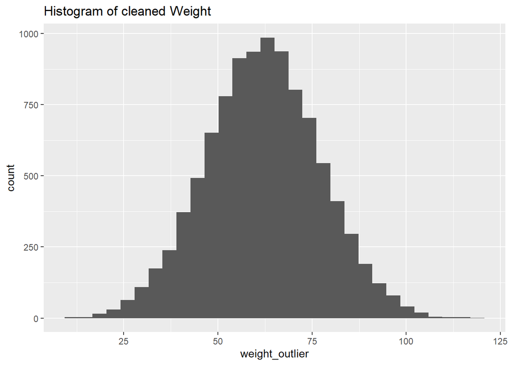

```r
hist_cleaned_weight <- ggplot(data = weight_cleaned_data, aes(weight_outlier)) +
                  geom_histogram() +
                ggtitle("Histogram of cleaned Weight")
plot(hist_cleaned_weight)
```

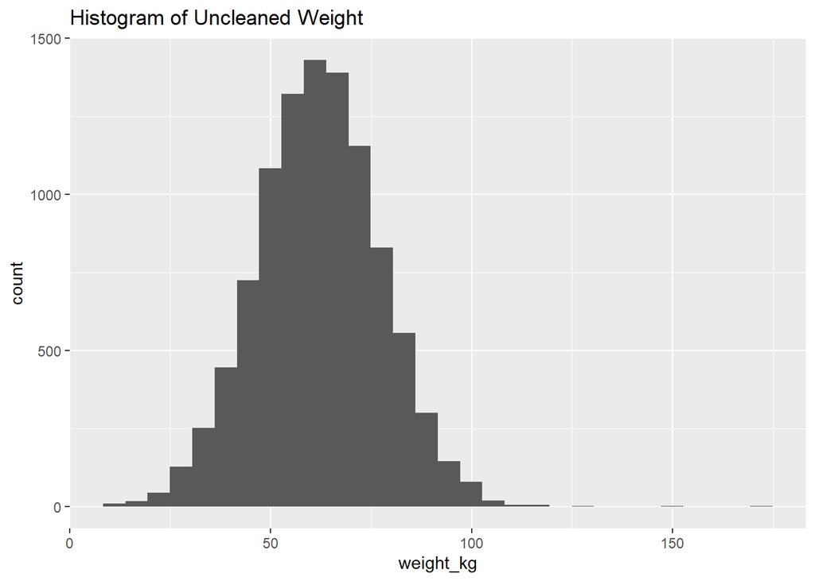

```r
plot(hist_weight)
```

The histogram of cleaned weight data suggests a normal distribution as opposed to that of the uncleaned weight data which suggested that the distribution of height was somewhat leptokurtic.

## Variable Analysis - BENCH PRESS MAX

- Variable type - Quantitative, Numeric, Continuous

We will use the weight cleaned data to analyze bench press max

```r
summary(weight_cleaned_data$bench_press_max_lbs)
```

```
##    Min. 1st Qu.  Median    Mean 3rd Qu.    Max.    NA's
##   55.59   69.33   92.16  109.25  135.27  500.00      16
```

### Are there outliers?

There appear to be outliers based on the summary statistics above. The maximum bench press max which is 500lbs might not be possible. More exploratory analysis of the variable is needed to see if there are outliers.

#### Let’s plot an histogram of bench press max

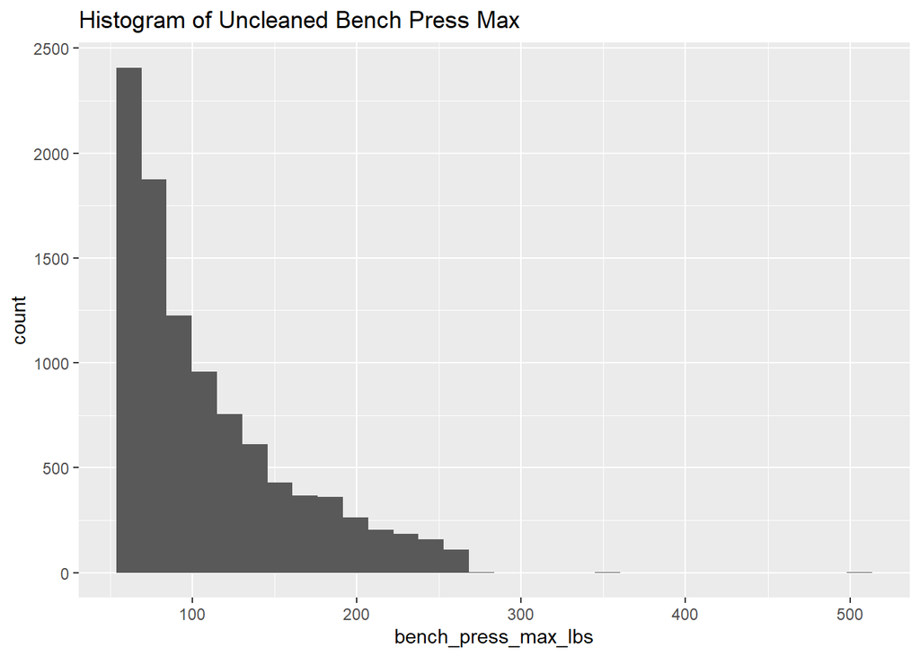

```r
hist_bench_press <- ggplot(data = weight_cleaned_data, aes(bench_press_max_lbs)) +
                  geom_histogram() +
                ggtitle("Histogram of Uncleaned Bench Press Max")
plot(hist_bench_press)
```

The histogram indicates that there are values outside the distribution. A boxplot will give more information about the outliers.

#### Let’s make a boxplot for bench press max

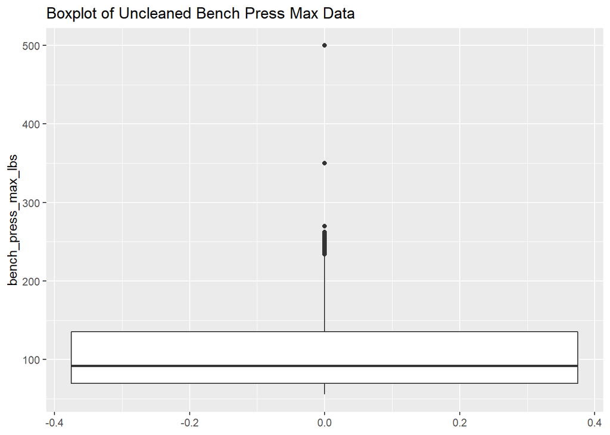

```r
box_bench_press <- ggplot(data = weight_cleaned_data, aes(bench_press_max_lbs)) +
                  geom_boxplot() +
                  ggtitle("Boxplot of Uncleaned Bench Press Max Data") +
                  coord_flip()
plot(box_bench_press)
```

The boxplot shows that there are two extreme values in the bench press data. It could be that the values were wrongly recorded or the participants were actually very strong. Let’s sort the variable in both ascending and descending orders to see the exact values of the extreme values.

```r
#arrange in descending order
head(arrange(weight_cleaned_data, desc(bench_press_max_lbs)), 10)
```

```
##      id age_years bench_press_max_lbs height_cm weight_kg height_outlier
## 1   280  35.62033            500.0000  163.9153  45.17775       163.9153
## 2   248  20.74785            350.0000  177.9113  64.96333       177.9113
## 3   193  31.57183            270.0000  182.1969  60.52423       182.1969
## 4  3726  18.01334            262.3057  162.1875  66.51877       162.1875
## 5  8509  18.01821            262.2346  160.1258  63.60764       160.1258
## 6   516  18.02647            262.1146  163.9895  58.16195       163.9895
## 7  8711  18.02713            262.1050  161.6748  74.86311       161.6748
## 8  7606  18.02924            262.0742  159.3542  37.45409       159.3542
## 9   903  18.03007            262.0622  129.8263  77.26702       129.8263
## 10 7356  18.03094            262.0496  181.5124  79.42527       181.5124
##    weight_outlier
## 1        45.17775
## 2        64.96333
## 3        60.52423
## 4        66.51877
## 5        63.60764
## 6        58.16195
## 7        74.86311
## 8        37.45409
## 9        77.26702
## 10       79.42527
```

```r
bench_no_outliers <- filter(weight_cleaned_data, is.na(bench_press_max_lbs) | bench_press_max_lbs < 270)
```

Let’s arrange the variable in ascending order to see the extreme values on the low end of the boxplot.

```r
#arranging height in ascending order
head(arrange(weight_cleaned_data, (bench_press_max_lbs)), 10)
```

```
##      id age_years bench_press_max_lbs height_cm weight_kg height_outlier
## 1  1092  84.99019            55.59465  145.9707  48.96224       145.9707
## 2  3954  84.97523            55.60444  162.0701  72.92510       162.0701
## 3  1134  84.97474            55.60476  159.3382  43.96873       159.3382
## 4  7232  84.97016            55.60776  152.1495  70.38246       152.1495
## 5   723  84.96809            55.60911  165.6570  63.09319       165.6570
## 6  2434  84.96796            55.60919  158.3583  61.79362       158.3583
## 7  5405  84.96153            55.61340  155.9181  54.13042       155.9181
## 8  3016  84.96151            55.61342  166.7351  69.88470       166.7351
## 9  7004  84.95320            55.61886  157.9361  56.23958       157.9361
## 10 3371  84.94801            55.62226  171.2408  78.59010       171.2408
##    weight_outlier
## 1        48.96224
## 2        72.92510
## 3        43.96873
## 4        70.38246
## 5        63.09319
## 6        61.79362
## 7        54.13042
## 8        69.88470
## 9        56.23958
## 10       78.59010
```

We can see here that there is no extreme low value in the bench press max variable.

### Comparing the outlier-cleaned data with the uncleaned data

We will compare the boxplots of the bench press data with and without outliers.

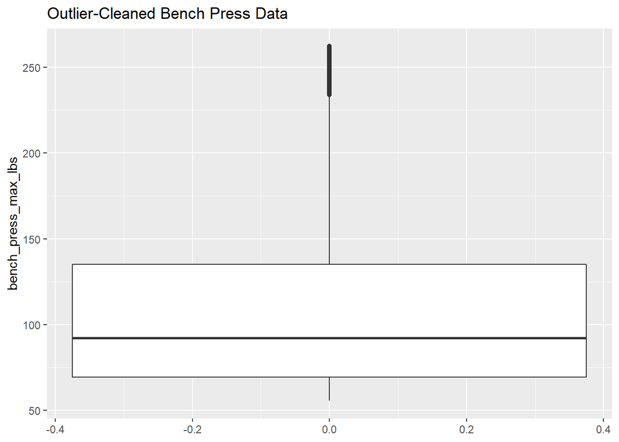

```r
#boxplots
box_bench_press_no_outlier <- ggplot() +
                  geom_boxplot(data = bench_no_outliers, aes(bench_press_max_lbs)) +
                  ggtitle("Outlier-Cleaned Bench Press Data") +
                  coord_flip()
#boxplot for outlier-cleaned data
plot(box_bench_press_no_outlier)
```

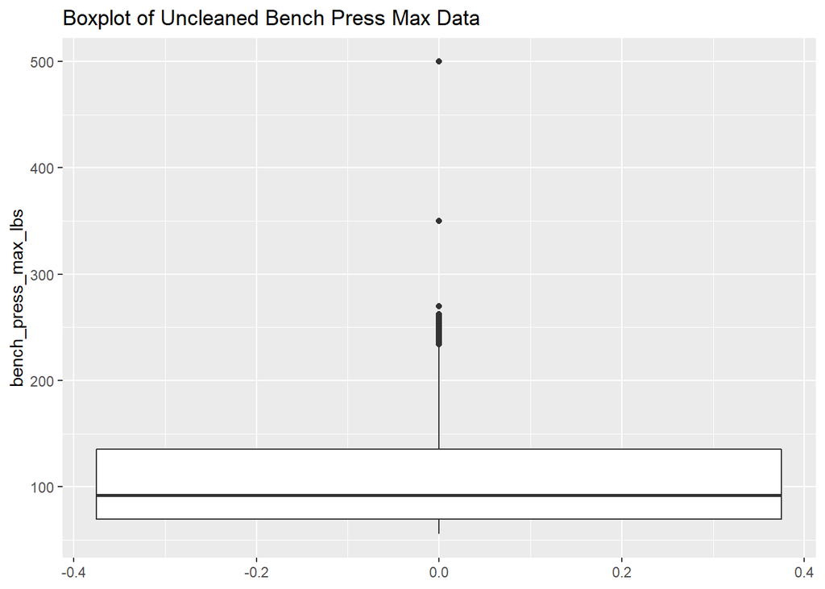

```r
#boxplot for uncleaned data
plot(box_bench_press)
```

## Are there missing data?

We will check for missing data in our outlier-cleaned data: “bench_no_outliers”

```r
summary(bench_no_outliers$bench_press_max_lbs)
```

```
##    Min. 1st Qu.  Median    Mean 3rd Qu.    Max.    NA's
##   55.59   69.33   92.15  109.17  135.16  262.31      16
```

The summary function shows that there are 16 missing data. We can also use the is.na function to confirm this.

```r
bench_no_outliers %>%
  summarise(count = sum(is.na(bench_press_max_lbs)))
```

```
##   count
## 1    16
```

The is.na function also confirms that there are 16 missing data in our outlier-cleaned bench press max data. 16 missing values out of 9928 data points is a very small portion of the data. So I will remove the people with missing bench press max values leaving us with 9,912 observations.

```r
bench_cleaned_data <- drop_na(bench_no_outliers, bench_press_max_lbs)
```

Now, we have a cleaned dataset for bench press max. Let’s compare the distribution of the uncleaned and cleaned datasets.

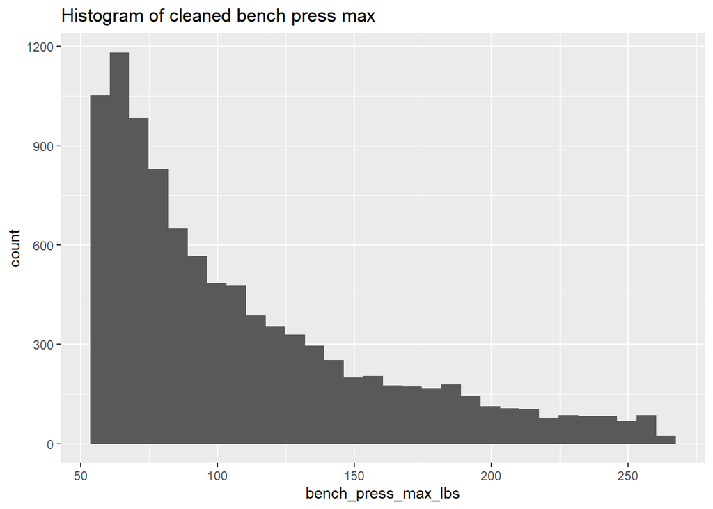

```r
hist_cleaned_bench <- ggplot(data = bench_cleaned_data, aes(bench_press_max_lbs)) +
                  geom_histogram() +
                ggtitle("Histogram of cleaned bench press max")
plot(hist_cleaned_bench)
```

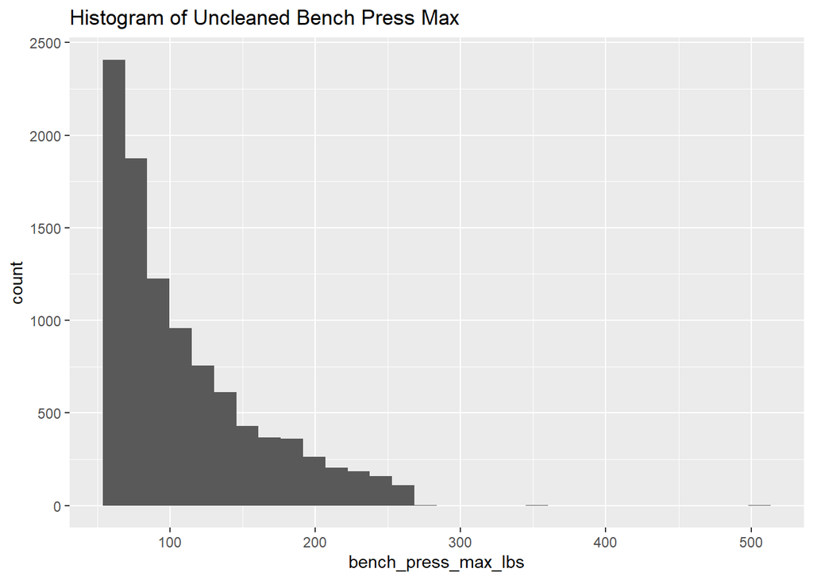

```r
plot(hist_bench_press)
```

The histogram of cleaned bench press max data suggests a more diverse poisson distribution as opposed to that of the uncleaned bench press max data.

### Compare the descriptive statistics of the cleaned and uncleaned bench press max data

```r
summary(weight_cleaned_data$bench_press_max_lbs)
```

```
##    Min. 1st Qu.  Median    Mean 3rd Qu.    Max.    NA's
##   55.59   69.33   92.16  109.25  135.27  500.00      16
```

```r
summary(bench_cleaned_data$bench_press_max_lbs)
```

```
##    Min. 1st Qu.  Median    Mean 3rd Qu.    Max.
##   55.59   69.33   92.15  109.17  135.16  262.31
```

There is also little to no difference between the mean and median of the cleaned and uncleaned bench press data.